# Final Project

Ruidi Chang (ID: ruidic)

Completed: 2022/12/14

```r
library(tidyverse)
library(data.table)
library(modelsummary)
library(ggplot2)
library(ggpubr)
library(plotly)
library(reshape2)
library(plyr)
set.seed(1)
```

## Crime Data from 2020 to Present in the City of Los Angele

This dataset reflects incidents of crime in the City of Los Angeles dating back to 2020. I am curious what is the pattern of crimes in LA. For example, which crime type happens most frequently? Is there any difference of crimes in different area? How can we predict crime type and what attributes are related to crime type?

This project will answer these questions and hopefully could give you some insight into LA’s criminal record.

Source of dataset: https://data.lacity.org/Public-Safety/Crime-Data-from-2020-to-Present/2nrs-mtv8

The variables that I extracted are listed below.

```r
Crime <- read.csv("Crime_Data_from_2020_to_Present.csv", stringsAsFactors=TRUE)
str(Crime)
```

```
## 'data.frame':    623105 obs. of  28 variables:
##  $ DR_NO         : int  10304468 190101086 200110444 191501505 191921269 200100501 200100502 200100504 200100507 201710201 ...
##  $ Date.Rptd     : Factor w/ 1077 levels "01/01/2020 12:00:00 AM",..: 22 4 311 1 1 4 4 10 10 509 ...
##  $ DATE.OCC      : Factor w/ 1077 levels "01/01/2020 12:00:00 AM",..: 22 1 130 1 1 1 4 10 10 437 ...
##  $ TIME.OCC      : int  2230 330 1200 1730 415 30 1315 40 200 1925 ...
##  $ AREA          : int  3 1 1 15 19 1 1 1 1 17 ...
##  $ AREA.NAME     : Factor w/ 21 levels "77th Street",..: 16 2 2 9 8 2 2 2 2 3 ...
##  $ Rpt.Dist.No   : int  377 163 155 1543 1998 163 161 155 101 1708 ...
##  $ Part.1.2      : int  2 2 2 2 2 1 1 2 1 1 ...
##  $ Crm.Cd        : int  624 624 845 745 740 121 442 946 341 341 ...
##  $ Crm.Cd.Desc   : Factor w/ 137 levels "ARSON","ASSAULT WITH DEADLY WEAPON ON POLICE OFFICER",..: 5 5 100 130 129 95 104 84 118 118 ...
##  $ Mocodes       : Factor w/ 217046 levels "","0100","0100 0104",..: 73877 65726 153217 15615 11084 58899 149987 145045 174026 132541 ...
##  $ Vict.Age      : int  36 25 0 76 31 25 23 0 23 0 ...
##  $ Vict.Sex      : Factor w/ 5 levels "","F","H","M",..: 2 4 5 2 5 2 4 5 4 5 ...
##  $ Vict.Descent  : Factor w/ 20 levels "","A","B","C",..: 3 8 19 18 19 8 8 19 3 19 ...
##  $ Premis.Cd     : int  501 102 726 502 409 735 404 726 502 203 ...
##  $ Premis.Desc   : Factor w/ 307 levels "","7TH AND METRO CENTER (NOT LINE SPECIFIC)",..: 257 256 237 209 25 214 57 237 209 220 ...
##  $ Weapon.Used.Cd: int  400 500 NA NA NA 500 NA NA NA NA ...
##  $ Weapon.Desc   : Factor w/ 79 levels "","AIR PISTOL/REVOLVER/RIFLE/BB GUN",..: 66 76 1 1 1 76 1 1 1 1 ...
##  $ Status        : Factor w/ 6 levels "AA","AO","CC",..: 2 4 1 4 4 4 4 4 4 2 ...
##  $ Status.Desc   : Factor w/ 6 levels "Adult Arrest",..: 2 3 1 3 3 3 3 3 3 2 ...
##  $ Crm.Cd.1      : int  624 624 845 745 740 121 442 946 341 341 ...
##  $ Crm.Cd.2      : int  NA NA NA 998 NA 998 998 998 998 NA ...
##  $ Crm.Cd.3      : int  NA NA NA NA NA NA NA NA NA NA ...
##  $ Crm.Cd.4      : int  NA NA NA NA NA NA NA NA NA NA ...
##  $ LOCATION      : Factor w/ 59848 levels "00    17TH                         AV",..: 4858 43907 20694 38157 12671 43871 43894 20694 43343 6885 ...
##  $ Cross.Street  : Factor w/ 8828 levels "","10                           FY",..: 1 1 1 1 1 1 1 1 1 1 ...
##  $ LAT           : num  34 34 34 34.2 34.2 ...
##  $ LON           : num  -118 -118 -118 -118 -118 ...
```

```r
dim(Crime)
```

```
## [1] 623105     28
```

The descriptions for the variables:

1. DR_NO: Division of Records Number: Official file number made up of a 2 digit year, area ID, and 5 digits (Unique identifier for each crime in this dataset)
2. Date Rptd: Reported Date: MM/DD/YYYY
3. DATE OCC: Occurred Date: MM/DD/YYYY
4. TIME OCC: Occurred Time: In 24 hour military time.
5. AREA: The LAPD has 21 Community Police Stations referred to as Geographic Areas within the department. These Geographic Areas are sequentially numbered from 1-21.
6. AREA NAME: The 21 Geographic Areas or Patrol Divisions are also given a name designation that references a landmark or the surrounding community that it is responsible for. For example 77th Street Division is located at the intersection of South Broadway and 77th Street, serving neighborhoods in South Los Angeles.
7. Rpt Dist No: A four-digit code that represents a sub-area within a Geographic Area. All crime records reference the “RD” that it occurred in for statistical comparisons. Find LAPD Reporting Districts on the LA City GeoHub at http://geohub.lacity.org/datasets/c4f83909b81d4786aa8ba8a74a4b4db1_4
8. Part 1-2
9. Crm Cd: Indicates the crime committed. (Same as Crime Code 1)
10. Crm Cd Desc: Defines the Crime Code provided.
11. Mocodes: Modus Operandi: Activities associated with the suspect in commission of the crime.See attached PDF for list of MO Codes in numerical order. https://data.lacity.org/api/views/y8tr-7khq/files/3a967fbd-f210-4857-bc52-60230efe256c?download=true&filename=MO%20CODES%20(numerical%20order).pdf
12. Vict Age: Two character numeric
13. Vict Sex: F - Female M - Male X - Unknown
14. Vict Descent: Descent Code: A - Other Asian B - Black C - Chinese D - Cambodian F - Filipino G - Guamanian H - Hispanic/Latin/Mexican I - American Indian/Alaskan Native J - Japanese K - Korean L - Laotian O - Other P - Pacific Islander S - Samoan U - Hawaiian V - Vietnamese W - White X - Unknown Z - Asian Indian
15. Premis Cd: The type of structure, vehicle, or location where the crime took place.
16. Premis Desc: Defines the Premise Code provided.
17. Weapon Used Cd: The type of weapon used in the crime.
18. Weapon Desc: Defines the Weapon Used Code provided.
19. Status: Status of the case. (IC is the default)
20. Status Desc: Defines the Status Code provided.
21. Crm Cd 1: Indicates the crime committed. Crime Code 1 is the primary and most serious one. Crime Code 2, 3, and 4 are respectively less serious offenses. Lower crime class numbers are more serious.
22. Crm Cd 2: May contain a code for an additional crime, less serious than Crime Code 1.
23. Crm Cd 3: May contain a code for an additional crime, less serious than Crime Code 1.
24. Crm Cd 4: May contain a code for an additional crime, less serious than Crime Code 1.
25. LOCATION: Street address of crime incident rounded to the nearest hundred block to maintain anonymity.
26. Cross Street: Cross Street of rounded Address
27. LAT: Latitude
28. LON: Longtitude

## Data Cleaning and Overview

```r
# Have a general view of the data and check the nulls
summary(Crime)
```

```
##      DR_NO                            Date.Rptd
##  Min.   :      817   05/02/2022 12:00:00 AM:   909
##  1st Qu.:201716755   04/04/2022 12:00:00 AM:   883
##  Median :211222936   06/02/2022 12:00:00 AM:   879
##  Mean   :211590010   11/02/2022 12:00:00 AM:   863
##  3rd Qu.:220617763   05/03/2022 12:00:00 AM:   861
##  Max.   :229921795   08/01/2022 12:00:00 AM:   841
##                      (Other)               :617869
##                    DATE.OCC         TIME.OCC         AREA
##  01/01/2020 12:00:00 AM:  1041   Min.   :   1   Min.   : 1.00
##  04/01/2022 12:00:00 AM:   986   1st Qu.: 900   1st Qu.: 6.00
##  06/01/2022 12:00:00 AM:   964   Median :1415   Median :11.00
##  05/02/2022 12:00:00 AM:   961   Mean   :1336   Mean   :10.72
##  07/01/2022 12:00:00 AM:   952   3rd Qu.:1900   3rd Qu.:16.00
##  05/01/2022 12:00:00 AM:   950   Max.   :2359   Max.   :21.00
##  (Other)               :617251
##        AREA.NAME       Rpt.Dist.No      Part.1.2         Crm.Cd
##  Central    : 41028   Min.   : 101   Min.   :1.000   Min.   :110.0
##  77th Street: 39597   1st Qu.: 622   1st Qu.:1.000   1st Qu.:330.0
##  Pacific    : 36182   Median :1142   Median :1.000   Median :442.0
##  Southwest  : 34883   Mean   :1119   Mean   :1.416   Mean   :501.9
##  Hollywood  : 33811   3rd Qu.:1617   3rd Qu.:2.000   3rd Qu.:626.0
##  Southeast  : 32107   Max.   :2199   Max.   :2.000   Max.   :956.0
##  (Other)    :405497
##                                                   Crm.Cd.Desc
##  VEHICLE - STOLEN                                       : 67683
##  BATTERY - SIMPLE ASSAULT                               : 49577
##  BURGLARY FROM VEHICLE                                  : 39266
##  VANDALISM - FELONY ($400 & OVER, ALL CHURCH VANDALISMS): 39031
##  THEFT OF IDENTITY                                      : 38361
##  BURGLARY                                               : 38004
##  (Other)                                                :351183
##       Mocodes          Vict.Age      Vict.Sex    Vict.Descent      Premis.Cd
##           : 85906   Min.   : -1.00    : 82168   H      :191858   Min.   :101
##  0344     : 25861   1st Qu.: 12.00   F:230166   W      :128865   1st Qu.:101
##  0329     : 14879   Median : 31.00   H:    71   B      : 90299   Median :203
##  1822 0344:  6788   Mean   : 29.98   M:259903          : 82173   Mean   :303
##  1501     :  6199   3rd Qu.: 45.00   X: 50797   X      : 56661   3rd Qu.:501
##  0344 1822:  4805   Max.   :120.00              O      : 49345   Max.   :971
##  (Other)  :478667                               (Other): 23904   NA's   :7
```

[output cut: 25 more lines]

```
##  Min.   :821.0    800 N  ALAMEDA                      ST:  1152
##  1st Qu.:998.0    6TH                          ST       :  1066
##  Median :998.0    7TH                                   :  1063
##  Mean   :989.3    7TH                          ST       :  1012
##  3rd Qu.:998.0    6TH                                   :   979
##  Max.   :999.0    FIGUEROA                     ST       :   853
##  NA's   :623061   (Other)                               :616980
##                           Cross.Street         LAT             LON
##                                 :519537   Min.   : 0.00   Min.   :-118.7
##  BROADWAY                       :  1673   1st Qu.:34.01   1st Qu.:-118.4
##  FIGUEROA                     ST:  1293   Median :34.06   Median :-118.3
##  VERMONT                      AV:  1072   Mean   :33.95   Mean   :-117.9
##  FIGUEROA                       :  1066   3rd Qu.:34.16   3rd Qu.:-118.3
##  WESTERN                      AV:  1011   Max.   :34.33   Max.   :   0.0
##  (Other)                        : 97453
```

```r
sum(is.na(Crime))
```

```
## [1] 2224284
```

Most of “na” occurs in “Crm.Cd.1”,“Crm.Cd.2”, “Crm.Cd.3” and “Crm.Cd.4”. In this project, Crm.cd is enough, so I decide to remove this column.

```r
drop <- c("Crm.Cd.1","Crm.Cd.2", "Crm.Cd.3", "Crm.Cd.4")
Crime <- Crime[,!(names(Crime) %in% drop)]
Crime <- subset(Crime, Vict.Sex != "")
Crime <- subset(Crime, Vict.Sex != " ")
Crime <- subset(Crime, Vict.Descent != "")
Crime <- subset(Crime, Vict.Age != -1)
Crime <- subset(Crime, Vict.Age != 0.00)
summary(Crime)
```

```
##      DR_NO                            Date.Rptd
##  Min.   : 10304468   05/02/2022 12:00:00 AM:   740
##  1st Qu.:201807156   06/02/2022 12:00:00 AM:   711
##  Median :211223090   04/04/2022 12:00:00 AM:   709
##  Mean   :211619102   05/03/2022 12:00:00 AM:   680
##  3rd Qu.:220617022   11/02/2022 12:00:00 AM:   675
##  Max.   :229904986   08/03/2022 12:00:00 AM:   674
##                      (Other)               :467954
##                    DATE.OCC         TIME.OCC         AREA
##  01/01/2020 12:00:00 AM:   920   Min.   :   1   Min.   : 1.00
##  05/02/2022 12:00:00 AM:   829   1st Qu.: 900   1st Qu.: 5.00
##  04/01/2022 12:00:00 AM:   812   Median :1400   Median :11.00
##  06/01/2022 12:00:00 AM:   788   Mean   :1323   Mean   :10.69
##  06/02/2022 12:00:00 AM:   788   3rd Qu.:1845   3rd Qu.:16.00
##  05/01/2022 12:00:00 AM:   785   Max.   :2359   Max.   :21.00
##  (Other)               :467221
##        AREA.NAME       Rpt.Dist.No      Part.1.2         Crm.Cd
##  Central    : 32551   Min.   : 101   Min.   :1.000   Min.   :110.0
##  77th Street: 30339   1st Qu.: 589   1st Qu.:1.000   1st Qu.:330.0
##  Southwest  : 29640   Median :1134   Median :1.000   Median :440.0
##  Pacific    : 26161   Mean   :1116   Mean   :1.486   Mean   :500.6
##  Hollywood  : 25731   3rd Qu.:1623   3rd Qu.:2.000   3rd Qu.:627.0
##  Southeast  : 24296   Max.   :2199   Max.   :2.000   Max.   :956.0
##  (Other)    :303425
##                                                   Crm.Cd.Desc
##  BATTERY - SIMPLE ASSAULT                               : 48965
##  BURGLARY FROM VEHICLE                                  : 38114
##  THEFT OF IDENTITY                                      : 37598
##  ASSAULT WITH DEADLY WEAPON, AGGRAVATED ASSAULT         : 35050
##  INTIMATE PARTNER - SIMPLE ASSAULT                      : 31709
##  VANDALISM - FELONY ($400 & OVER, ALL CHURCH VANDALISMS): 29359
##  (Other)                                                :251348
##       Mocodes          Vict.Age     Vict.Sex    Vict.Descent      Premis.Cd
##  0344     : 22116   Min.   : 2.00    :     0   H      :188698   Min.   :101.0
##  0329     : 10970   1st Qu.:28.00   F:227600   W      :119799   1st Qu.:104.0
##  1822 0344:  6086   Median :37.00   H:    69   B      : 89234   Median :403.0
##  1501     :  4449   Mean   :39.57   M:239220   O      : 41376   Mean   :331.6
##  0344 1822:  4163   3rd Qu.:50.00   X:  5254   A      : 13201   3rd Qu.:502.0
##  0329 1300:  3616   Max.   :99.00              X      :  9412   Max.   :971.0
##  (Other)  :420743                              (Other): 10423
```

[output cut: 17 more lines]

```
##  Adult Arrest: 43085   7TH                                   :   939
##  Adult Other : 62094   800 N  ALAMEDA                      ST:   873
##  Invest Cont :364632   6TH                                   :   870
##  Juv Arrest  :  1520   6TH                          ST       :   842
##  Juv Other   :   811   7TH                          ST       :   796
##  UNK         :     1   5TH                                   :   739
##                        (Other)                               :467084
##                           Cross.Street         LAT             LON
##                                 :392813   Min.   : 0.00   Min.   :-118.7
##  BROADWAY                       :  1281   1st Qu.:34.01   1st Qu.:-118.4
##  FIGUEROA                     ST:  1006   Median :34.06   Median :-118.3
##  VERMONT                      AV:   858   Mean   :33.95   Mean   :-117.9
##  FIGUEROA                       :   848   3rd Qu.:34.16   3rd Qu.:-118.3
##  SAN PEDRO                      :   834   Max.   :34.33   Max.   :   0.0
##  (Other)                        : 74503
```

```r
sum(is.na(Crime))
```

```
## [1] 270350
```

Now there’s much less null in this data

## Exploratory Data Analysis

### 1. General statistical information about the data

```r
datasummary_skim(Crime) # A general charts to see some statistic results of the data
```

Unique (#)

Missing (%)

Mean

SD

Min

Median

Max

DR_NO

472143

0

211619102.4

8159422.8

10304468.0

211223090.0

229904986.0

[figure not shown]

TIME.OCC

1439

0

1323.2

652.7

1.0

1400.0

2359.0

[figure not shown]

AREA

21

0

10.7

6.1

1.0

11.0

21.0

[figure not shown]

Rpt.Dist.No

1173

0

1115.8

614.7

101.0

1134.0

2199.0

[figure not shown]

Part.1.2

2

0

1.5

0.5

1.0

1.0

2.0

[figure not shown]

Crm.Cd

133

0

500.6

222.6

110.0

440.0

956.0

[figure not shown]

Vict.Age

98

0

39.6

15.5

2.0

37.0

99.0

[figure not shown]

Premis.Cd

306

0

331.6

216.6

101.0

403.0

971.0

[figure not shown]

Weapon.Used.Cd

79

57

363.9

121.0

101.0

400.0

516.0

[figure not shown]

LAT

5240

0

34.0

2.0

0.0

34.1

34.3

[figure not shown]

LON

4934

0

−117.9

7.1

−118.7

−118.3

0.0

[figure not shown]

From this chart, we can see how these features spread out from the standard deviation and small histograms on the right.

The standard deviation for Vict.age is huge (15.5), so it is widely spread. The mean value (39.6) is similar with its median value (37), meaning that it’s kind of normal distribution, with a bit right skewed. The mini histogram shows the same thing.

From the mini histogram of TIME.OCC, we can could that the crime is almost happen in uniform distribution. Afternoon and night is a bit more than morning.

From the histogram of Crm.Cd, we can see that there is a significantly high number of crimes in some crime type. The following analysis will tell us what are they.

### 2. Grouping the data by race

After having a general view of the dataset, we can take a look at the variables in the groups that we are interested in.

Data summary for crimes happened in different Area:

```r
sort(table(Crime$AREA.NAME), decreasing = T) # number of crimes by the AREA name.
```

```
##
##     Central 77th Street   Southwest     Pacific   Hollywood   Southeast
##       32551       30339       29640       26161       25731       24296
##    Wilshire N Hollywood     Olympic     West LA     Topanga      Newton
##       23008       22935       22641       22040       21886       21596
##     Rampart    Van Nuys     Mission West Valley   Northeast      Harbor
##       21487       21138       19576       19312       19066       18268
##  Devonshire    Foothill  Hollenbeck
##       18021       16322       16129
```

Central Area has most crimes and Hollenbeck has least.

Data summary for crimes happened in Central Area:

```r
Central <- subset(Crime, AREA.NAME == "Central")
head(sort(table(Central$Crm.Cd.Desc), decreasing = T)) # 6 most frequently crime type in Central
```

```
##
##                                   BURGLARY FROM VEHICLE
##                                                    5410
##                                BATTERY - SIMPLE ASSAULT
##                                                    4420
##          ASSAULT WITH DEADLY WEAPON, AGGRAVATED ASSAULT
##                                                    2631
##                      THEFT PLAIN - PETTY ($950 & UNDER)
##                                                    2222
## VANDALISM - FELONY ($400 & OVER, ALL CHURCH VANDALISMS)
##                                                    1835
##                                                 ROBBERY
##                                                    1630
```

Burglary occurs most often in Central Area.

Data summary for crimes happened in Hollenbeck Area:

```r
Hollenbeck <- subset(Crime, AREA.NAME == "Hollenbeck")
head(sort(table(Hollenbeck$Crm.Cd.Desc), decreasing = T)) # 6 most frequently crime type in Hollenbeck
```

```
##
##                                BATTERY - SIMPLE ASSAULT
##                                                    2102
##          ASSAULT WITH DEADLY WEAPON, AGGRAVATED ASSAULT
##                                                    1648
##                                       THEFT OF IDENTITY
##                                                    1343
##                       INTIMATE PARTNER - SIMPLE ASSAULT
##                                                    1166
## VANDALISM - FELONY ($400 & OVER, ALL CHURCH VANDALISMS)
##                                                    1108
##                                   BURGLARY FROM VEHICLE
##                                                     805
```

Battery occurs most often in Hollenbeck Area.

Data summary for victim age:

```r
sort(table(Crime$Vict.Age), decreasing =T) # Victim age.
```

```
##
##    30    35    29    31    28    32    27    33    26    25    34    24    36
## 14378 14001 13714 13617 13524 13310 12915 12738 12665 12344 12169 11651 11622
##    37    38    39    23    40    21    41    22    42    43    50    44    20
## 11115 10931 10434 10328 10209  9571  9538  9321  9001  8806  8564  8374  8323
##    45    46    47    51    49    48    52    19    53    54    55    56    57
##  8089  7616  7550  7235  7222  7149  6957  6949  6616  6394  6352  5984  5901
##    58    59    60    61    62    63    64    18    65    66    67    17    68
##  5643  5502  5174  4854  4607  4377  4105  3928  3718  3422  2999  2789  2636
##    16    69    70    15    71    72    14    73    74    13    75    12    76
##  2470  2352  2240  2208  2029  1889  1775  1740  1493  1492  1272  1103  1095
##    77    78    79    11    80    81    82    10    83     9     7     8    85
##  1043   907   779   754   701   605   590   514   495   465   391   391   387
##     5    84     6     4    86     3     2    87    99    88    89    90    91
##   385   374   363   341   322   318   278   232   219   214   191   180   149
##    92    93    94    95    96    98    97
##   110    75    75    64    55    47    40
```

Most Victims are in 20s or 30s.

Data summary for victim sex:

```r
table(Crime$Vict.Sex) # Victim sex.
```

```
##
##             F      H      M      X
##      0 227600     69 239220   5254
```

Victims sex has no obvious bias.

Data summary for victim descent:

```r
sort(table(Crime$Vict.Descent), decreasing =T) # Victim race.
```

```
##
##      H      W      B      O      A      X      K      F      C      J      V
## 188698 119799  89234  41376  13201   9412   3175   2446   2146    809    596
##      I      Z      P      U      D      G      L      S
##    557    294    153     96     44     43     35     29      0
```

Most victims are Hispanic/Latin/Mexican.

Data summary for crimes tpye:

```r
head(sort(table(Crime$Crm.Cd.Desc), decreasing =T)) # 6 most frequency crime type.
```

```
##
##                                BATTERY - SIMPLE ASSAULT
##                                                   48965
##                                   BURGLARY FROM VEHICLE
##                                                   38114
##                                       THEFT OF IDENTITY
##                                                   37598
##          ASSAULT WITH DEADLY WEAPON, AGGRAVATED ASSAULT
##                                                   35050
##                       INTIMATE PARTNER - SIMPLE ASSAULT
##                                                   31709
## VANDALISM - FELONY ($400 & OVER, ALL CHURCH VANDALISMS)
##                                                   29359
```

Battery, burglary and theft is the top 3 most frequency crime type.

Cross tabulation by area and victim sex:

```r
table(Crime$AREA.NAME, Crime$Vict.Sex) # cross tabulation by area and victim sex
```

```
##
##                         F     H     M     X
##   77th Street     0 17225     0 12899   215
##   Central         0 13048     1 19400   102
##   Devonshire      0  8698     1  9277    45
##   Foothill        0  8091     1  8221     9
##   Harbor          0  9831     2  8356    79
##   Hollenbeck      0  8289     3  7813    24
##   Hollywood       0 11298     2 14340    91
##   Mission         0  9780     2  9667   127
##   N Hollywood     0 10796     3 12107    29
##   Newton          0 10901    17 10608    70
##   Northeast       0  9100     5  9903    58
##   Olympic         0 10871     5 11632   133
##   Pacific         0 11569     2 14504    86
##   Rampart         0 10350     5 10850   282
##   Southeast       0 14378     9  9803   106
##   Southwest       0 14458     2 12017  3163
##   Topanga         0  9265     1 12610    10
##   Van Nuys        0  9971     4 11128    35
##   West LA         0 10042     0 11935    63
##   West Valley     0  9260     0 10047     5
##   Wilshire        0 10379     4 12103   522
```

In 77th Street and Southeast, female victims is much more than male. In Central, male victims is much more than female. For other areas, there is no significant different.

## Graphical Exploratory Data Analysis

### Graphical Exploratory Data Analysis - Victim

#### 1. The bar plot in victims

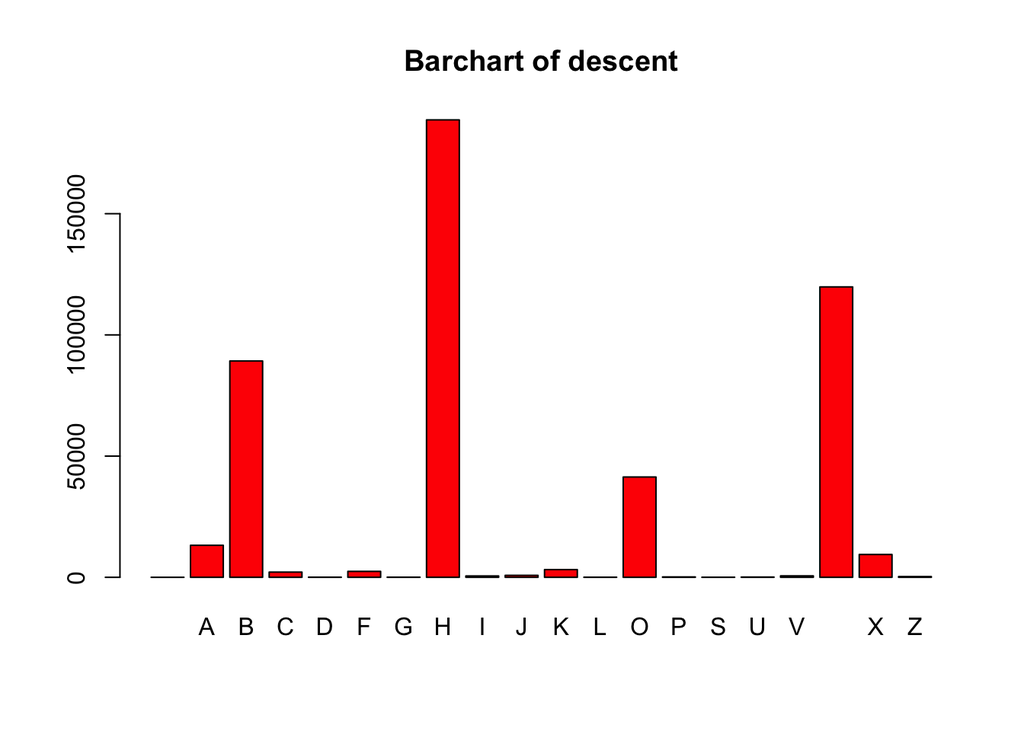

```r
barplot(table(Crime$Vict.Descent),
        main = 'Barchart of descent',
        col = 'red')
```

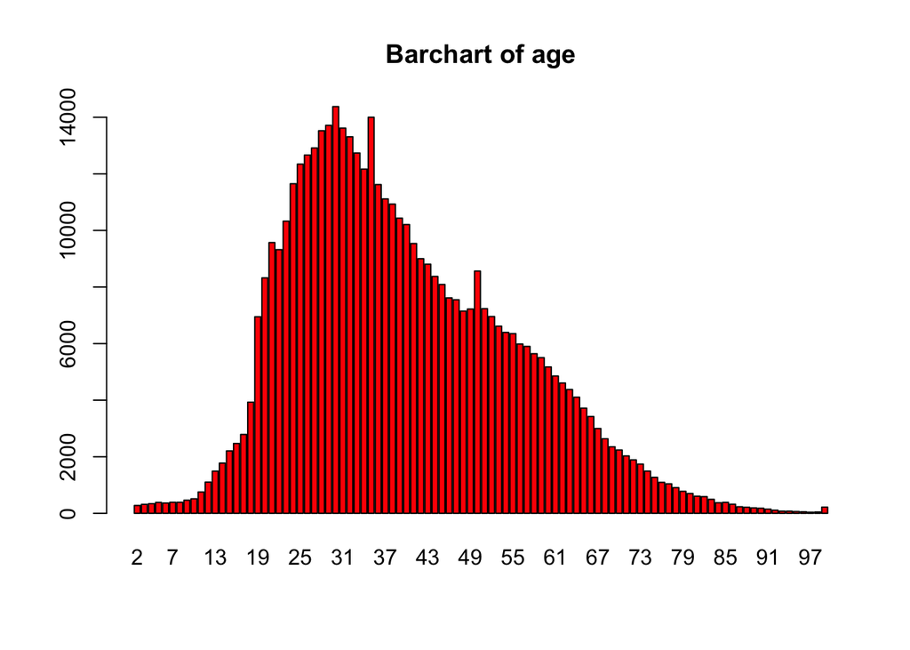

```r
barplot(table(Crime$Vict.Age),
        main = 'Barchart of age',
        col = 'red')
```

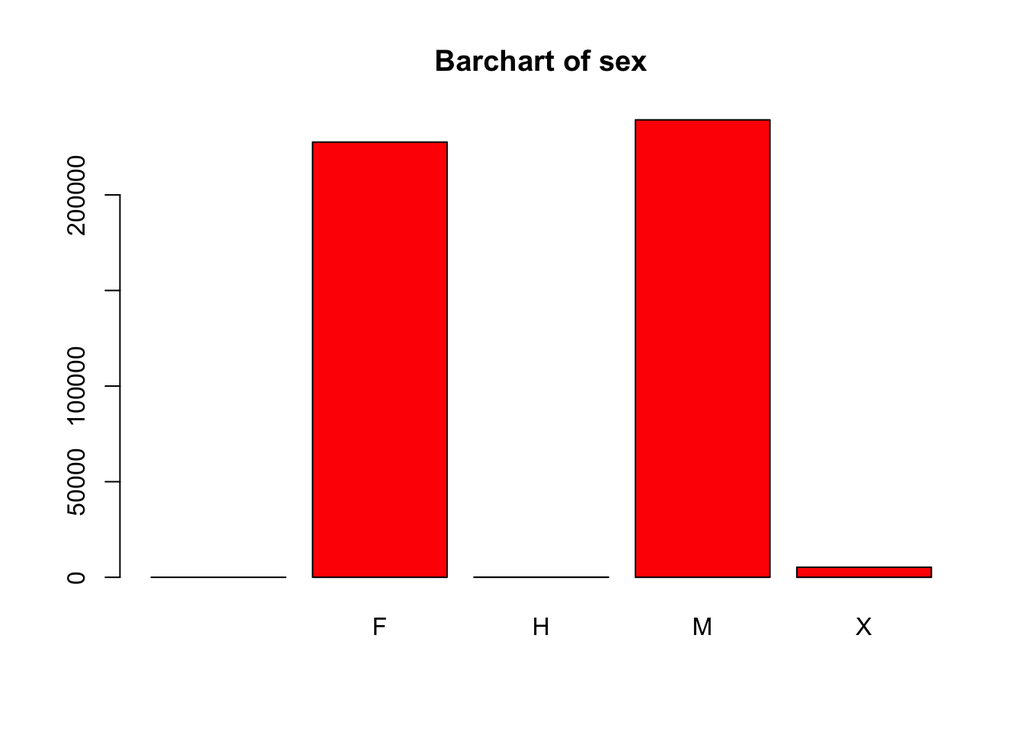

```r
barplot(table(Crime$Vict.Sex),
        main = 'Barchart of sex',
        col = 'red')
```

#### 2. Checking the distributions

To make sure that the two groups are similarly distributed in their exogenous features (i.e. age), we can make some plots to specifically see the distribution

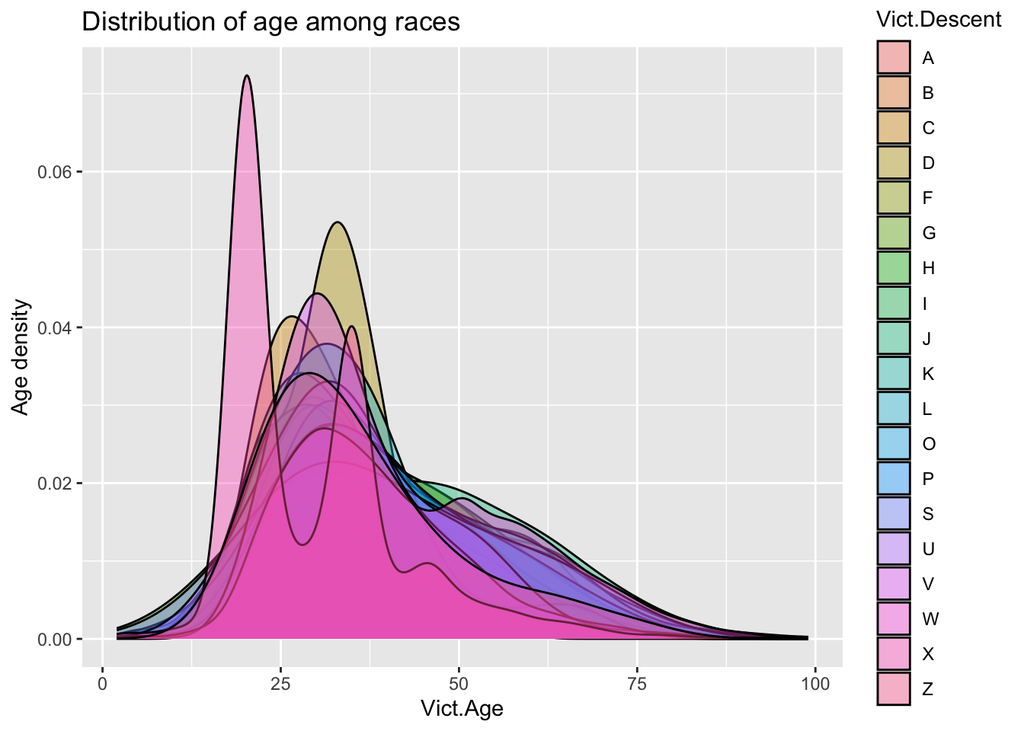

```r
# Source for this part: https://www.r-graph-gallery.com/135-stacked-density-graph.html
age_distr <- ggplot(Crime, aes(x=Vict.Age, group=Vict.Descent, fill=Vict.Descent), scale= 2) + geom_density(adjust=1.5, alpha=.4) + ggtitle('Distribution of age among races') + ylab("Age density")
age_distr
```

It seems that the age among races is distributed similarly for most races. However, for Asian Indian, there are two peaks at about 20 years old and 35 years old. All the age is right-skewed.

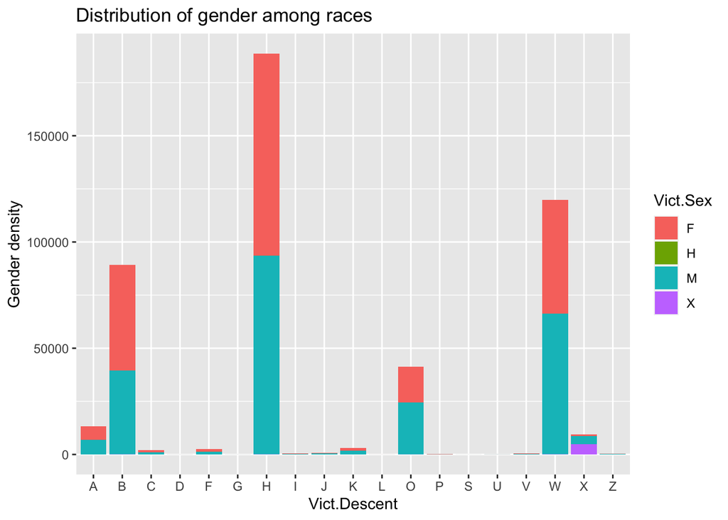

```r
gender_distr <- ggplot(Crime, aes(x=Vict.Descent, fill=Vict.Sex)) + geom_bar() + ggtitle('Distribution of gender among races') + ylab("Gender density")
gender_distr
```

It seems that the gender among races is distributed similarly because they are all half-to-half.

We can think that among the races, gender and age are distributed similarly. So we can think that the exogenous features are not different between these two groups.

#### 3. The box plot in victims

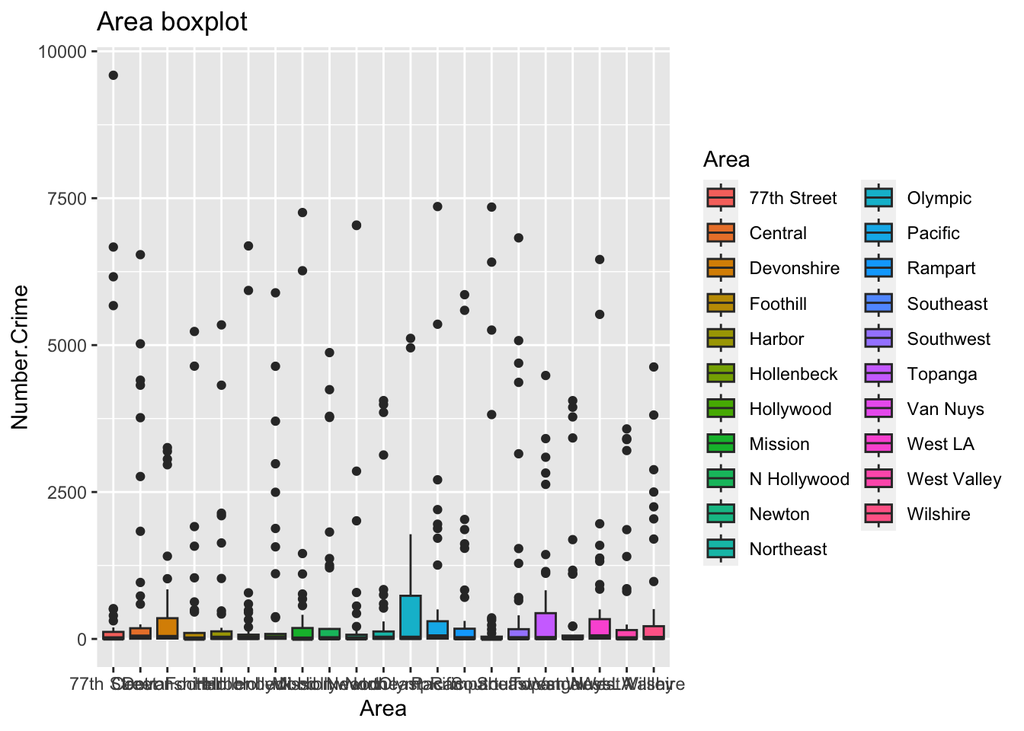

```r
Crime_area_vict <- aggregate(x = Crime$DR_NO, by = list(Crime$AREA.NAME, Crime$Vict.Descent, Crime$Vict.Sex), length)
colnames(Crime_area_vict) <- c("Area", "Descent", "Sex", "Number.Crime")
box_area <- ggplot(Crime_area_vict, aes(x=Area, y=Number.Crime, fill=Area)) + geom_boxplot() + ggtitle('Area boxplot')
box_area
```

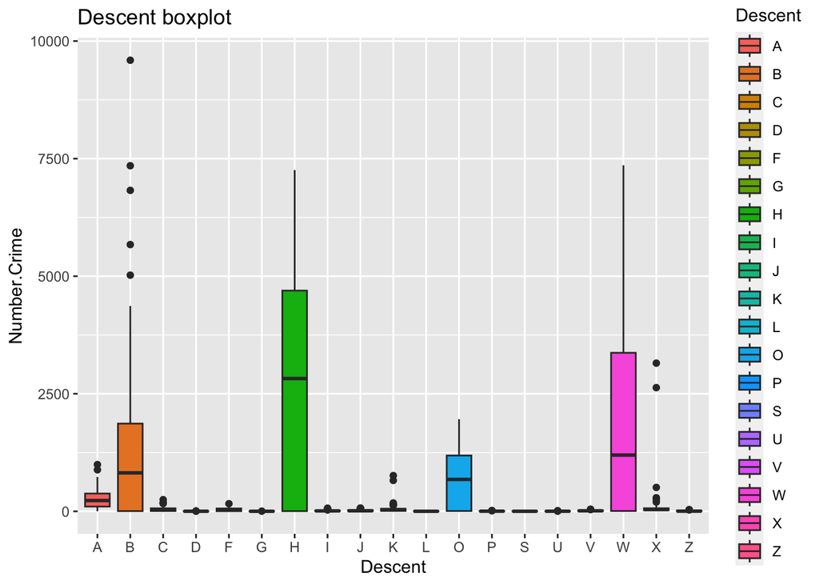

```r
box_race <- ggplot(Crime_area_vict, aes(x=Descent, y=Number.Crime, fill=Descent)) + geom_boxplot() + ggtitle('Descent boxplot')
box_race
```

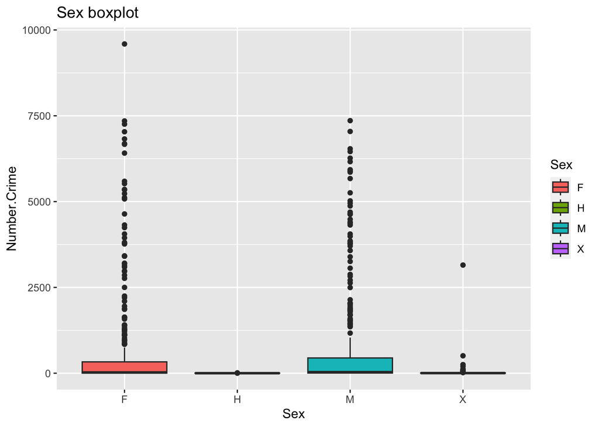

```r
box_sex <- ggplot(Crime_area_vict, aes(x=Sex, y=Number.Crime, fill=Sex)) + geom_boxplot() + ggtitle('Sex boxplot')
box_sex
```

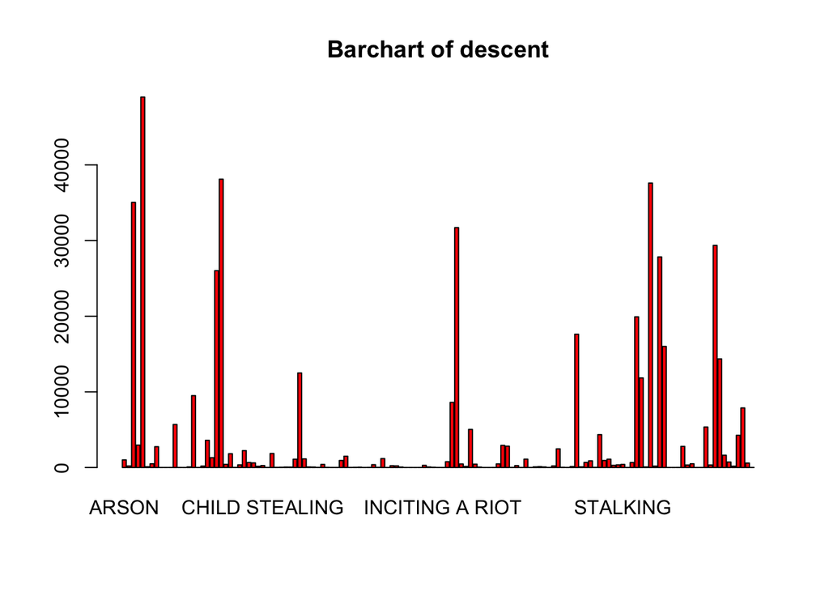

```r
barplot(table(Crime$Crm.Cd.Desc),
        main = 'Barchart of descent',
        col = 'red')
```

Battery, burglary and theft is the top 3 most frequency crime type.

#### 2. Checking the distributions

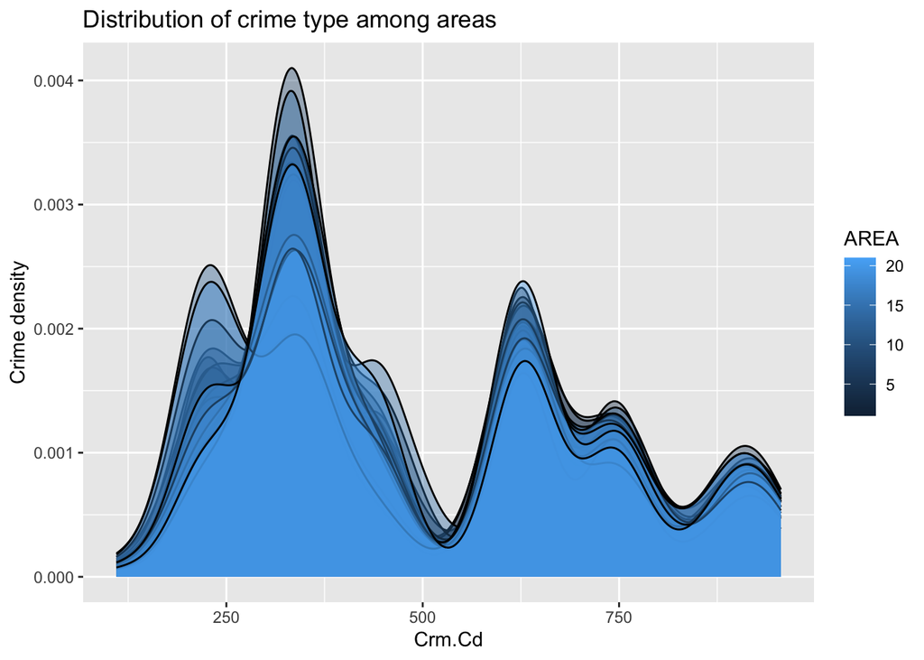

```r
type_distr <- ggplot(Crime, aes(x=Crm.Cd, group=AREA, fill=AREA), scale= 2) + geom_density(adjust=1.5, alpha=.4) + ggtitle('Distribution of crime type among areas') + ylab("Crime density")
type_distr
```

The crime type in different areas is similar.

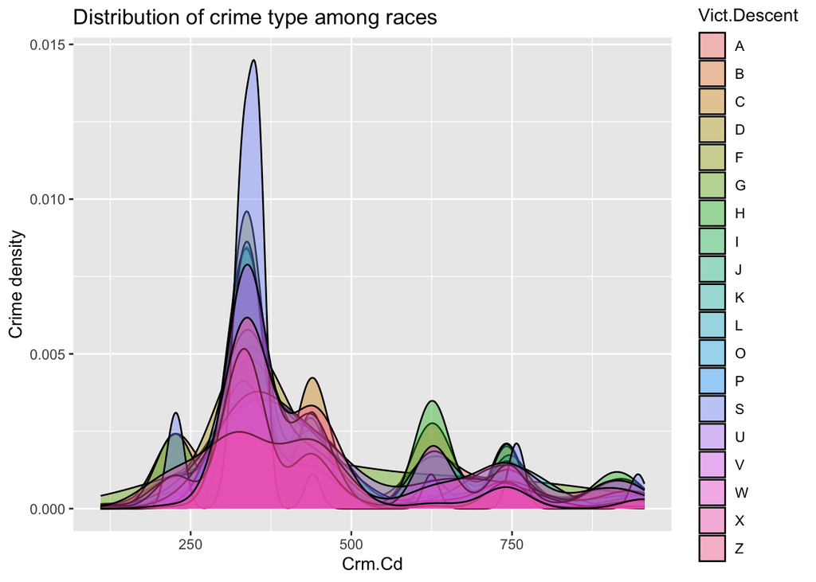

```r
type_race_distr <- ggplot(Crime, aes(x=Crm.Cd, group=Vict.Descent, fill=Vict.Descent), scale= 2) + geom_density(adjust=1.5, alpha=.4) + ggtitle('Distribution of crime type among races') + ylab("Crime density")
type_race_distr
```

The distributions of crime type in different races are similar. However, races like Samoan has higher kurtosis.

## Deeper Analysis

### 1. Statistical comparing

We have observed some potential differences in crime type. However, some statistical methods are still needed to make what we saw more convincing.

Firstly, we can compare their crime type in different sex.

```r
female <- Crime$Crm.Cd[Crime$Vict.Sex == "F"]
male <- Crime$Crm.Cd[Crime$Vict.Sex == "M"]
t.test(female, male, conf.level = 0.95)
```

```
##
##  Welch Two Sample t-test
##
## data:  female and male
## t = 85.215, df = 462952, p-value < 2.2e-16
## alternative hypothesis: true difference in means is not equal to 0
## 95 percent confidence interval:
##  53.90570 56.44378
## sample estimates:
## mean of x mean of y
##  528.8576  473.6829
```

Unlike what we infer in the graphing part, the crime type difference between the female and male is statistically significant because the p-vale < 0.05.

However, it still needs to be tested later by statistical models like Linear Regressions.

### 2. Regressions

Although the result for 2 variables simple linear regression should be similar to the t-test, we can still generate a linear regression model and observe its coefficients to give us some basic ideas.

```r
Crime_subsex <- subset(Crime, Vict.Sex == "F" | Vict.Sex == "M")
Crime_lm1 <- lm(Crm.Cd ~ Vict.Sex, data = Crime_subsex)
summary(Crime_lm1)
```

```
##
## Call:
## lm(formula = Crm.Cd ~ Vict.Sex, data = Crime_subsex)
##
## Residuals:
##     Min      1Q  Median      3Q     Max
## -418.86 -174.86  -53.68  152.32  482.32
##
## Coefficients:
##             Estimate Std. Error t value Pr(>|t|)
## (Intercept) 528.8576     0.4630  1142.2   <2e-16 ***
## Vict.SexM   -55.1747     0.6468   -85.3   <2e-16 ***
## ---
## Signif. codes:  0 '***' 0.001 '**' 0.01 '*' 0.05 '.' 0.1 ' ' 1
##
## Residual standard error: 220.9 on 466818 degrees of freedom
## Multiple R-squared:  0.01535,    Adjusted R-squared:  0.01535
## F-statistic:  7277 on 1 and 466818 DF,  p-value: < 2.2e-16
```

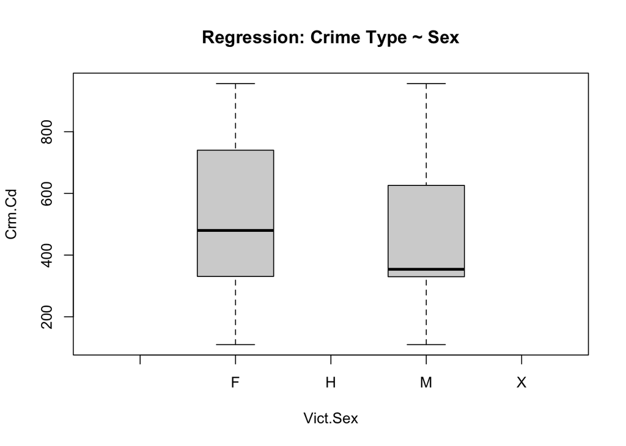

```r
plot(x=Crime_subsex$Vict.Sex, y=Crime_subsex$Crm.Cd, xlab='Vict.Sex', ylab='Crm.Cd', main='Regression: Crime Type ~ Sex')
```

The result above still tells us that crime type for different sex is statistically significant.

#### Longer Linear Regression for crime type:

Now we can try to add more variables.

Before that, we need to check the correlation between the variables to reduce the effect of multi-collinearity.

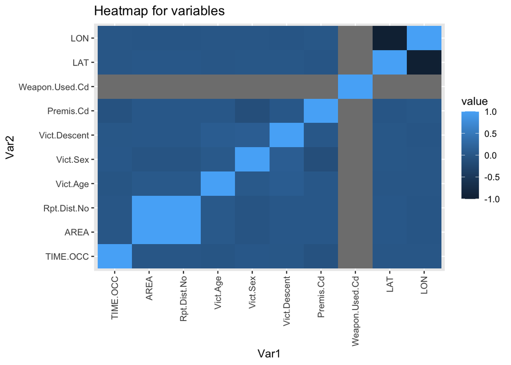

```r
# Source for this part: http://www.sthda.com/english/wiki/ggplot2-quick-correlation-matrix-heatmap-r-software-and-data-visualization
Crime$Vict.Sex <- revalue(Crime$Vict.Sex, c("F"=0,"M"=1,"H"=2,"X"=3))
Crime$Vict.Descent <- revalue(Crime$Vict.Descent, c("A"=0,"B"=1,"C"=2,"D"=3,"F"=4,"G"=5,"H"=6,"I"=7,"J"=8,"K"=9,"L"=10,"O"=11,"P"=12,"S"=13,"U"=14,"V"=15,"W"=16,"X"=17,"Z"=18))
Crime$Vict.Descent <- as.numeric(Crime$Vict.Descent)
Crime$Vict.Sex <- as.numeric(Crime$Vict.Sex)
Crime_x <- Crime[, c(4,5,7,12,13,14,15,17,23,24)]
corr <- round(cor(Crime_x), 2)
melted_corr <- melt(corr)
heatmap <- ggplot(data = melted_corr, aes(x=Var1, y=Var2, fill=value)) + geom_tile() + theme(axis.text.x=element_text(angle=90,hjust=1,vjust=0.5)) + ggtitle('Heatmap for variables')
heatmap
```

```r
Crime_lm2 <- lm(Crm.Cd ~
                   TIME.OCC
                 + AREA
                 + Rpt.Dist.No
                 + Vict.Age
                 + Vict.Sex
                 + Vict.Descent
                 + Weapon.Used.Cd
                 + LAT
                 + LON,
                 data = Crime)
summary(Crime_lm2)
```

```
##
## Call:
## lm(formula = Crm.Cd ~ TIME.OCC + AREA + Rpt.Dist.No + Vict.Age +
##     Vict.Sex + Vict.Descent + Weapon.Used.Cd + LAT + LON, data = Crime)
##
## Residuals:
##     Min      1Q  Median      3Q     Max
## -554.50 -160.08   59.24  106.75  677.82
##
## Coefficients:
##                  Estimate Std. Error t value Pr(>|t|)
## (Intercept)     3.775e+02  8.510e+00  44.361  < 2e-16 ***
## TIME.OCC        8.467e-03  7.228e-04  11.713  < 2e-16 ***
## AREA           -2.188e+00  1.854e+00  -1.181  0.23779
## Rpt.Dist.No     2.086e-02  1.857e-02   1.123  0.26144
## Vict.Age       -1.023e-01  3.189e-02  -3.207  0.00134 **
## Vict.Sex       -2.113e+01  4.936e-01 -42.794  < 2e-16 ***
## Vict.Descent    4.398e-01  9.652e-02   4.557 5.19e-06 ***
## Weapon.Used.Cd  7.661e-01  4.120e-03 185.941  < 2e-16 ***
## LAT             6.421e+01  5.193e+00  12.364  < 2e-16 ***
## LON             1.926e+01  1.496e+00  12.870  < 2e-16 ***
## ---
## Signif. codes:  0 '***' 0.001 '**' 0.01 '*' 0.05 '.' 0.1 ' ' 1
##
## Residual standard error: 217.9 on 201783 degrees of freedom
##   (270350 observations deleted due to missingness)
## Multiple R-squared:  0.1734, Adjusted R-squared:  0.1733
## F-statistic:  4703 on 9 and 201783 DF,  p-value: < 2.2e-16
```

From the above Linear Regression, we can see that the effect of Area and Rpt.Dist.No on Crm.Cd is not statistically significant. Now it’s more likely that area has no causal effect on crime type.

Let remove this two varibles.

```r
Crime_lm3 <- lm(Crm.Cd ~
                   TIME.OCC
                 + Vict.Age
                 + Vict.Sex
                 + Vict.Descent
                 + Weapon.Used.Cd
                 + LAT
                 + LON,
                 data = Crime)
summary(Crime_lm3)
```

```
##
## Call:
## lm(formula = Crm.Cd ~ TIME.OCC + Vict.Age + Vict.Sex + Vict.Descent +
##     Weapon.Used.Cd + LAT + LON, data = Crime)
##
## Residuals:
##     Min      1Q  Median      3Q     Max
## -555.66 -159.97   59.42  106.82  678.80
##
## Coefficients:
##                  Estimate Std. Error t value Pr(>|t|)
## (Intercept)     3.774e+02  8.419e+00  44.826  < 2e-16 ***
## TIME.OCC        8.448e-03  7.227e-04  11.690  < 2e-16 ***
## Vict.Age       -1.017e-01  3.188e-02  -3.190  0.00142 **
## Vict.Sex       -2.109e+01  4.931e-01 -42.778  < 2e-16 ***
## Vict.Descent    4.397e-01  9.651e-02   4.556 5.21e-06 ***
## Weapon.Used.Cd  7.663e-01  4.118e-03 186.075  < 2e-16 ***
## LAT             6.258e+01  5.091e+00  12.293  < 2e-16 ***
## LON             1.879e+01  1.467e+00  12.809  < 2e-16 ***
## ---
## Signif. codes:  0 '***' 0.001 '**' 0.01 '*' 0.05 '.' 0.1 ' ' 1
##
## Residual standard error: 217.9 on 201785 degrees of freedom
##   (270350 observations deleted due to missingness)
## Multiple R-squared:  0.1734, Adjusted R-squared:  0.1733
## F-statistic:  6046 on 7 and 201785 DF,  p-value: < 2.2e-16
```

The attributes related to victims(age, sex, race) has effect on crime type. The crime occurrence time and weapon usage also have effect on crime type.

## Conclusion

To answer the questions I mentioned at the begining of this project.

Battery, burglary and theft is the top 3 most frequency crime type. The distribution of crime types in different areas is similar, but each area has its most frequent crime type. For example, Burglary occurs most often in Central Area and Battery occurs most often in Hollenbeck Area. In 77th Street and Southeast, female victims is much more than male. In Central, male victims is much more than female. For other areas, there is no significant different.

From t-test, we conclude that the crime type difference between the female and male is statistically significant.

To predict crime type, crime occurrence time, victim, weapons and locations are good attributes.